# Doubly Robust Estimation of Causal Effects in Survival Analysis

2025-11-02

```r
knitr::opts_chunk$set(
  collapse = TRUE,
  comment = "#>"
)
options(warn = -1)
set.seed(123456)
library(survival)
library(pseudo)
library(adjustedCurves)
library(MASS)
library(ggplot2)
library(survminer)
library(dplyr)
library(knitr)
library(kableExtra)
```

## Introduction

As noted in Funk (2011), estimating causal effects of a treatment in observational studies is challenging due to confounding bias. Common approaches to control for confounding include outcome regression and propensity score methods. Outcome regression methods model the conditional expectation of the outcome given treatment and covariates. Propensity score methods estimate the probability of receiving treatment given covariates. Inverse probability weighting uses propensity scores to create a pseudo-population in which treatment is independent of measured confounders. Both approaches rely on correct model specification because misspecification of either model can lead to biased estimates.

## Doubly Robust Estimation

Following Funk (2011), doubly robust (DR) estimation combines outcome regression and propensity score methods. The DR estimator is consistent if either model is correctly specified. In this setting, we consider $n$ subject, and $i$ indexes individual subject. Let $D$ denote the treatment indicator (0 or 1), $Y$ the outcome of interest, and $\boldsymbol{Z} = (Z_1, Z_2, \ldots, Z_k)$ the vector of baseline covariates. $e(\boldsymbol{Z}_i)$ represents the estimated propensity score for each individual, and $m_d(\boldsymbol{Z}_i)$ is the predicted outcome given treatment and baseline covariates. The average treatment effect (ATE) can be estimated as $\hat{\tau}_{DR} = \frac{1}{n} \sum_{i=1}^n \left[ \frac{D_i Y_i}{e(\boldsymbol{Z}_i)} - \frac{(D_i - e(\boldsymbol{Z}_i)) }{e(\boldsymbol{Z}_i)} m_1(\boldsymbol{Z}_i) \right] - \left[ \frac{(1 - D_i) Y_i}{1 - e(\boldsymbol{Z}_i)} + \frac{(D_i - e(\boldsymbol{Z}_i)) }{1 - e(\boldsymbol{Z}_i)} m_0(\boldsymbol{Z}_i) \right]$. Fundamental causal inference assumptions—exchangeability, positivity, consistency, and no interference—still hold. The DR method still assumes that all confounders are measured, since unmeasured confounding can introduce bias. For detailed mathematical derivations, please refer to Funk (2011). According to Tsiatis (2006), the estimator can achieve semiparametric efficiency bounds when both models are correctly specified.

## R Code Demo

This demonstration starts with data simulation.

```r
generate_data <- function(n = 3000) {
  mu <- rep(0, 3)
  sigma <- matrix(c(1, 0, 0, 0, 1, 0, 0, 0, 1), nrow = 3)
  Z <- mvrnorm(n, mu, sigma)
  Z1 <- Z[, 1]
  Z2 <- Z[, 2]
  Z3 <- Z[, 3]

  logit_p <- (0.35 * Z1 + 0.7 * Z2 + 1.05 * Z3)/3
  p <- exp(logit_p) / (1 + exp(logit_p))
  D <- rbinom(n, 1, p) # Treatment indicator

  hazard <- exp(-1 + D + 1 * Z1 + 2 * Z2 + 1 * Z1 * Z2)

  T_event <- rexp(n, rate = hazard) # Event time
  T_censor <- rexp(n, rate = exp(-4.5)) # Censoring time
  T_admin <- rep(7, n) # Administrative censoring at fixed time

  Time <- pmin(T_event, T_censor, T_admin) # Observed time
  Event <- as.numeric(T_event <= T_censor & T_event <= T_admin) # Event indicator

  return(data.frame(Z1 = Z1, Z2 = Z2, Z3 = Z3, D = D, Time = Time, Event = Event))
}

# -----------------------------
# Data Dictionary:
# Z1, Z2, Z3: baseline covariates
# D: treatment indicator (1 = treated, 0 = control)
# Time: observed time
# Event: event indicator (1 if event occurred, 0 otherwise)
# -----------------------------

data <- generate_data()
summary(data$Time)
```

```
#>      Min.   1st Qu.    Median      Mean   3rd Qu.      Max.
#> 0.0000012 0.1550828 1.1591579 2.5427131 5.3168373 7.0000000
```

```r
table(data$Event)
```

```
#>
#>    0    1
#>  729 2271
```

It is important to check the proportional hazards assumption.

```r
# 1. Schoenfeld Residuals plot: A flat middle line indicates that the proportional hazards assumption holds.
cox_check_model <- coxph(Surv(Time, Event) ~ D, data = data)
cox.zph(cox_check_model) #p-value
```

```
#>        chisq df      p
#> D       7.07  1 0.0078
#> GLOBAL  7.07  1 0.0078
```

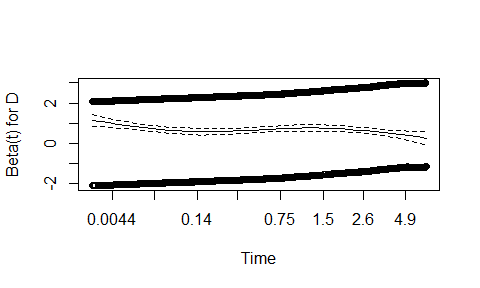

```r
plot(cox.zph(cox_check_model))
```

```r
#Explanations from Copilot: The two dark horizontal lines around 2 and -2 are reference boundaries for the residuals. They help assess whether the residuals fall within an acceptable range: If most of the residuals lie within these boundaries, it suggests that the proportional hazards assumption is likely valid. If residuals consistently fall outside these lines, it may indicate a violation of the assumption.
#remove later???
```

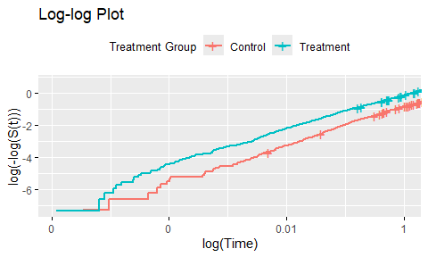

```r
# 2. Log-log plot: Parallel lines indicate proportional hazards assumption is met.
surv_fit <- survfit(Surv(Time, Event) ~ D, data = data)
ggsurvplot(surv_fit, data = data, fun = "cloglog",
           title = "Log-log Plot", xlab = "log(Time)",
           legend.title = "Treatment Group",
           legend.labs = c("Control", "Treatment"),
           ggtheme = theme(legend.text = element_text(size = 9),
              legend.title = element_text(size = 10)))
```

We will compare four model specification scenarios:

- Scenario 1: Both the outcome model and the propensity score model are correctly specified.
- Scenario 2: The propensity score model is correctly specified, but the outcome model is misspecified.
- Scenario 3: The outcome model is correctly specified, while the propensity score model is misspecified.
- Scenario 4: Both models are misspecified.

Below is the DR estimation function using R packages.

```r
ps_model <- glm(D ~ Z1 + Z2 + Z3, data = data, family = "binomial")
summary(ps_model)
```

```
#>
#> Call:
#> glm(formula = D ~ Z1 + Z2 + Z3, family = "binomial", data = data)
#>
#> Coefficients:
#>             Estimate Std. Error z value Pr(>|z|)
#> (Intercept)  0.01600    0.03735   0.428    0.668
#> Z1           0.17520    0.03763   4.656 3.22e-06 ***
#> Z2           0.24797    0.03800   6.525 6.79e-11 ***
#> Z3           0.31148    0.03795   8.207 2.27e-16 ***
#> ---
#> Signif. codes:  0 '***' 0.001 '**' 0.01 '*' 0.05 '.' 0.1 ' ' 1
#>
#> (Dispersion parameter for binomial family taken to be 1)
#>
#>     Null deviance: 4158.4  on 2999  degrees of freedom
#> Residual deviance: 4024.2  on 2996  degrees of freedom
#> AIC: 4032.2
#>
#> Number of Fisher Scoring iterations: 4
```

```r
dr_ate_package <- function(data, times, ps_correct = TRUE, or_correct = TRUE) {

  # Propensity score model
  if (ps_correct) {
    ps_model <- glm(D ~ Z1 + Z2 + Z3, data = data, family = "binomial")
  } else {
    ps_model <- glm(D ~ Z1, data = data, family = "binomial")
  }

  # Outcome regression covariates
  if (or_correct) {
    data$Z1_Z2 <- data$Z1 * data$Z2
    or_covars <- c("Z1", "Z2", "Z1_Z2")
  } else {
    or_covars <- c("Z1", "Z3")
  }

  data$D <- as.factor(data$D)

  adj_surv <- adjustedsurv(
    data = data,
    variable = "D",
    ev_time = "Time",
    event = "Event",
    method = "aiptw_pseudo",
    treatment_model = ps_model,
    outcome_vars = or_covars,
    times = times,
    conf_int = TRUE)

  # Survival probabilities and confidence intervals for the treated group
  surv_1 <- adj_surv$adj[adj_surv$adj$group == 1, c("surv", "ci_lower", "ci_upper")]
  # Survival probabilities and confidence intervals for the control group
  surv_0 <- adj_surv$adj[adj_surv$adj$group == 0, c("surv", "ci_lower", "ci_upper")]

  ATE <- surv_1$surv - surv_0$surv
  ci_lower <- surv_1$ci_lower - surv_0$ci_upper
  ci_upper <- surv_1$ci_upper - surv_0$ci_lower

  return(list(ATE = ATE, ci_lower = ci_lower, ci_upper = ci_upper))
}

# Note: package function "aiptw_pseudo" method uses a generalized estimation equation for outcome model, which is different from the manual implementation.
```

The analysis can be conducted at multiple time points.

```r
times <- c(3, 4, 5)
results_package <- dr_ate_package(data, times)
results_package_tbl <- rbind(ATE = round(results_package$ATE, 2),
  `CI lower` = round(results_package$ci_lower, 2),
  `CI upper` = round(results_package$ci_upper, 2))

colnames(results_package_tbl) <- c("T=3", "T=4", "T=5")
kable(results_package_tbl, caption = "ATE and 95% Confidence Intervals") %>%
  kable_styling(full_width = FALSE, font_size = 12)
```

ATE and 95% Confidence Intervals

|  | T=3 | T=4 | T=5 |
| --- | --- | --- | --- |
| ATE | -0.16 | -0.17 | -0.16 |
| CI lower | -0.21 | -0.21 | -0.20 |
| CI upper | -0.12 | -0.13 | -0.12 |

Alternatively, the DR estimator can be implemented manually.

```r
dr_ate_manual <- function(data, times, ps_correct = TRUE, or_correct = TRUE) {

  # Split data by treatment group
  data_1 <- data[data$D == 1, ]
  data_0 <- data[data$D == 0, ]

  # Outcome regression (Cox proportional hazard model)
  if (or_correct) {
    or_model_1 <- coxph(Surv(Time, Event) ~ Z1 * Z2, data = data_1)
    or_model_0 <- coxph(Surv(Time, Event) ~ Z1 * Z2, data = data_0)
  } else {
    or_model_1 <- coxph(Surv(Time, Event) ~ Z1 + Z3, data = data_1)
    or_model_0 <- coxph(Surv(Time, Event) ~ Z1 + Z3, data = data_0)
  }

  # Linear predictors (Beta^T * Z)
  lp_1 <- predict(or_model_1, newdata = data, type = "lp")
  lp_0 <- predict(or_model_0, newdata = data, type = "lp")

  # Baseline survival functions
  base_surv_1 <- survfit(or_model_1, newdata = data.frame(Z1=0, Z2=0, Z3=0))
  base_surv_0 <- survfit(or_model_0, newdata = data.frame(Z1=0, Z2=0, Z3=0))

  # Baseline survival probabilities at different times
  s0_t_1 <- summary(base_surv_1, times = times, extend = TRUE)$surv
  s0_t_0 <- summary(base_surv_0, times = times, extend = TRUE)$surv

  # Predicted survival probabilities

  m1 <- sapply(s0_t_1, function(s) s^exp(lp_1))
  m0 <- sapply(s0_t_0, function(s) s^exp(lp_0))

  # Propensity scores
  if (ps_correct) {
    ps_model <- glm(D ~ Z1 + Z2 + Z3, data = data, family = "binomial")
  } else {
    ps_model <- glm(D ~ Z1, data = data, family = "binomial")
  }
  e <- predict(ps_model, type = "response")

  # Pseudo-observations (individual estimates of the survival function at specified time points)
  pseudo_obs <- pseudo::pseudosurv(time = data$Time, event = data$Event, tmax = times)$pseudo

  surv_1 <- numeric(length(times))
  surv_0 <- numeric(length(times))

  ATE <- numeric(length(times))

  for(j in 1:length(times)) {
    # DR for treated group
    term1_treated <- data$D * pseudo_obs[, j] / e
    term2_treated <- (data$D - e) * m1[, j] / e
    term_full_treated <- term1_treated - term2_treated
    surv_1[j] <- mean(term_full_treated)

    # DR for control group
    term1_control <- (1 - data$D) * pseudo_obs[, j] / (1 - e)
    term2_control <- (data$D - e) * m0[, j] / (1 - e)
    term_full_control <- term1_control + term2_control
    surv_0[j] <- mean(term_full_control)

    # ATE
    ATE[j] <- surv_1[j] - surv_0[j]
  }
  return(list(ATE = ATE))
}
```

```r
se_bootstrap <- function(data, times, num_boot = 100) {

  n <- nrow(data)
  boot_results <- matrix(NA, nrow = num_boot, ncol = length(times))

  for (b in 1:num_boot) {
    boot_indices <- sample(1:n, size = n, replace = TRUE)
    boot_data <- data[boot_indices, ]
    boot_results[b, ] <- dr_ate_manual(data = boot_data, times = times)$ATE
  }

  se <- apply(boot_results, 2, sd, na.rm = TRUE)
  return(list(se = se))
}
```

```r
results_manual <- dr_ate_manual(data, times)
se_manual <- se_bootstrap(data, times)

# Calculate 95% confidence intervals
results_manual$ci_lower <- results_manual$ATE - 1.96 * se_manual$se
results_manual$ci_upper <- results_manual$ATE + 1.96 * se_manual$se

results_manual_tbl <- rbind(ATE = round(results_manual$ATE, 2),
  `CI lower` = round(results_manual$ci_lower, 2),
  `CI upper` = round(results_manual$ci_upper, 2))

colnames(results_manual_tbl) <- c("T=3", "T=4", "T=5")
kable(results_manual_tbl, caption = "ATE and 95% Confidence Intervals") %>%
  kable_styling(full_width = FALSE, font_size = 12)
```

ATE and 95% Confidence Intervals

|  | T=3 | T=4 | T=5 |
| --- | --- | --- | --- |
| ATE | -0.16 | -0.17 | -0.16 |
| CI lower | -0.19 | -0.19 | -0.18 |
| CI upper | -0.14 | -0.15 | -0.14 |

Next, we calculate the true ATE.

```r
get_true_survival <- function(data, t, d_level) {
  hazard <- exp(-1 + d_level + 1 * data$Z1 + 2 * data$Z2 + 1 * data$Z1 * data$Z2)
  survival_probs <- exp(-hazard * t)
  return(mean(survival_probs))
}

true_surv_1 <- sapply(times, function(t) get_true_survival(data, t, d_level = 1))
true_surv_0 <- sapply(times, function(t) get_true_survival(data, t, d_level = 0))
results_true <- list(ATE = true_surv_1 - true_surv_0)
```

```r
# Scenario 1: Both models correct
results_1_package <- dr_ate_package(data, times, ps_correct = TRUE, or_correct = TRUE)
results_1_manual <- dr_ate_manual(data, times, ps_correct = TRUE, or_correct = TRUE)

# Scenario 2: PS correct, OR incorrect
results_2_package <- dr_ate_package(data, times, ps_correct = TRUE, or_correct = FALSE)
results_2_manual <- dr_ate_manual(data, times, ps_correct = TRUE, or_correct = FALSE)

# Scenario 3: PS incorrect, OR correct
results_3_package <- dr_ate_package(data, times, ps_correct = FALSE, or_correct = TRUE)
results_3_manual <- dr_ate_manual(data, times, ps_correct = FALSE, or_correct = TRUE)

# Scenario 4: Both models incorrect
results_4_package <- dr_ate_package(data, times, ps_correct = FALSE, or_correct = FALSE)
results_4_manual <- dr_ate_manual(data, times, ps_correct = FALSE, or_correct = FALSE)
```

```r
# Crude Cox model: Cox regression without covariates, no propensity score
crude_cox_estimator <- function(data, times) {

  crude_cox <- coxph(Surv(Time, Event) ~ D, data = data)
  treatment_effect <- coef(crude_cox)["D"]

  base_surv <- survfit(crude_cox)
  s0 <- summary(base_surv, times = times, extend = TRUE)$surv

  # survival for treated group: S_baseline^exp(beta_D)
  surv_1 <- s0^exp(treatment_effect)

  # survival for control group: S_baseline^exp(0)
  surv_0 <- s0

  # ATE
  ATE <- surv_1 - surv_0

  return(list(ATE = ATE))
}
results_crude <- crude_cox_estimator(data, times)
```

```r
scenarios <- c(
  "0: Crude Cox (Unadjusted)",
  "1: Both Correct",
  "2: PS Correct, OR Incorrect",
  "3: PS Incorrect, OR Correct",
  "4: Both Incorrect")

# Combine bias values across all time points into a single string
format_bias <- function(bias_vector) {
  paste(sprintf("%.3f", bias_vector), collapse = ", ")
}

# Package column (bias at T=1, T=1.5, T=2)
package_bias <- c("—",
  format_bias(sapply(1:length(times), function(i) results_1_package$ATE[i] - results_true$ATE[i])),
  format_bias(sapply(1:length(times), function(i) results_2_package$ATE[i] - results_true$ATE[i])),
  format_bias(sapply(1:length(times), function(i) results_3_package$ATE[i] - results_true$ATE[i])),
  format_bias(sapply(1:length(times), function(i) results_4_package$ATE[i] - results_true$ATE[i]))
)

# Manual column (bias at T=1, T=1.5, T=2)
manual_bias <- c(
  format_bias(sapply(1:length(times), function(i) results_crude$ATE[i] - results_true$ATE[i])),
  format_bias(sapply(1:length(times), function(i) results_1_manual$ATE[i] - results_true$ATE[i])),
  format_bias(sapply(1:length(times), function(i) results_2_manual$ATE[i] - results_true$ATE[i])),
  format_bias(sapply(1:length(times), function(i) results_3_manual$ATE[i] - results_true$ATE[i])),
  format_bias(sapply(1:length(times), function(i) results_4_manual$ATE[i] - results_true$ATE[i]))
)

bias_table <- data.frame(
  Scenario = scenarios,
  Package = package_bias,
  Manual = manual_bias
)

kable(bias_table,
      col.names = c("Scenario", "Package", "Manual"),
      caption = "Bias of ATE Estimates (T = 3, 4, 5)",
      align = c('l', 'c', 'c')) %>%
  kable_styling(full_width = FALSE, font_size = 12) %>%
  footnote(general = sprintf("True ATE: %.3f, %.3f, %.3f",
            results_true$ATE[1], results_true$ATE[2], results_true$ATE[3]),
           general_title = "", footnote_as_chunk = TRUE)
```

Bias of ATE Estimates (T = 3, 4, 5)

| Scenario | Package | Manual |
| --- | --- | --- |
| 0: Crude Cox (Unadjusted) | — | -0.086, -0.085, -0.083 |
| 1: Both Correct | -0.002, -0.013, -0.009 | -0.003, -0.013, -0.009 |
| 2: PS Correct, OR Incorrect | -0.008, -0.019, -0.015 | -0.008, -0.019, -0.015 |
| 3: PS Incorrect, OR Correct | -0.004, -0.015, -0.010 | -0.005, -0.015, -0.010 |
| 4: Both Incorrect | -0.074, -0.081, -0.073 | -0.073, -0.081, -0.072 |

True ATE: -0.161, -0.158, -0.154

```r
# remove later???
ps_model <- glm(D ~ Z1 + Z2 + Z3, data = data, family = "binomial")

true_ps_coef <- c("(Intercept)" = 0, "Z1" = 0.35/3, "Z2" = 0.7/3, "Z3" = 1.05/3)
fitted_ps_coef <- coef(ps_model)

ps_comparison <- data.frame(
  Variable = names(true_ps_coef),
  True = round(true_ps_coef, 4),
  Fitted = round(fitted_ps_coef, 4),
  Difference = round(fitted_ps_coef - true_ps_coef, 4)
)
print(ps_comparison, row.names = FALSE)
```

```
#>     Variable   True Fitted Difference
#>  (Intercept) 0.0000 0.0160     0.0160
#>           Z1 0.1167 0.1752     0.0585
#>           Z2 0.2333 0.2480     0.0146
#>           Z3 0.3500 0.3115    -0.0385
```

```r
data_1 <- data[data$D == 1, ]
cox_model_1 <- coxph(Surv(Time, Event) ~ Z1 * Z2, data = data_1)

true_cox_coef <- c("Z1" = 1, "Z2" = 2, "Z1:Z2" = 1)
fitted_cox_1 <- coef(cox_model_1)

cox1_comparison <- data.frame(
  Variable = names(true_cox_coef),
  True = round(true_cox_coef, 4),
  Fitted = round(fitted_cox_1, 4),
  Difference = round(fitted_cox_1 - true_cox_coef, 4)
)
print(cox1_comparison, row.names = FALSE)
```

```
#>  Variable True Fitted Difference
#>        Z1    1 0.9101    -0.0899
#>        Z2    2 1.8898    -0.1102
#>     Z1:Z2    1 1.0189     0.0189
```

```r
data_0 <- data[data$D == 0, ]
cox_model_0 <- coxph(Surv(Time, Event) ~ Z1 * Z2, data = data_0)

fitted_cox_0 <- coef(cox_model_0)

cox0_comparison <- data.frame(
  Variable = names(true_cox_coef),
  True = round(true_cox_coef, 4),
  Fitted = round(fitted_cox_0, 4),
  Difference = round(fitted_cox_0 - true_cox_coef, 4)
)
print(cox0_comparison, row.names = FALSE)
```

```
#>  Variable True Fitted Difference
#>        Z1    1 0.9706    -0.0294
#>        Z2    2 2.0572     0.0572
#>     Z1:Z2    1 1.0365     0.0365
```

```r
# remove later???
logit_p <- (0.35 * data$Z1 + 0.7 * data$Z2 + 1.05 * data$Z3) / 3
p_true <- exp(logit_p) / (1 + exp(logit_p))
print(summary(p_true))
```

```
#>    Min. 1st Qu.  Median    Mean 3rd Qu.    Max.
#>  0.1799  0.4285  0.5020  0.5024  0.5741  0.8298
```

```r
mean(p_true < 0.1)
```

```
#> [1] 0
```

# References

Funk, Westreich, M. J. 2011. “Doubly Robust Estimation of Causal Effects.” *American Journal of Epidemiology* 173 (7): 761–67.

J., Wang. 2018. “A Simple, Doubly Robust, Efficient Estimator for Survival Functions Using Pseudo Observations.” *Pharmaceutical Statistics* 17 (1): 38–48.

Tsiatis, Anastasios A. 2006. *Semiparametric Theory and Missing Data*. Springer Series in Statistics. New York, NY: Springer. https://doi.org/10.1007/0-387-37345-4.